# NFL_Data_Markdown

Joseph

9/30/2021

# Question

In fantasy-football the most important picks are in the early rounds and the decision on whether to draft a top tier Running Back or Receiver with your early round draft picks. The analysis is done for both PPR scoring leagues(+1 point for every reception) and standard scoring leagues.

# Cleaning and Processing Data

The tables ActivePlayer_Rushing_Stats and ActivePlayer_Receiving_Stats were initially downloaded from Kaggle (link:https://www.kaggle.com/trevyoungquist/2020-nfl-stats-active-and-retired-players).

The data initially looked like this:

NFL_Fantasy_Rushing:

- https://drive.google.com/file/d/1Ofe-dheIjS_G87KbPUYxcyfrbsuRhlhT/view?usp=sharing

NFL_Fantasy_Reciving:

- https://drive.google.com/file/d/1FyM86Qo7rJcUFKMO0a6nrbYfLs0x0EHc/view?usp=sharing

After downloading the data I moved it to spreadsheets where I removed any duplicates, trimmed whitespaces, analyzed the data for any outlandish data points, removed the irrelevant data, and added the columns that would relate to my data analysis (ex: Fantasy_Rushing_points or Fantasy_Standard_Reciving_Total).

Link to Spreadsheets:

- https://docs.google.com/spreadsheets/d/1Mm8hreJhZO6MvhHdWcmCHCb93yO1ciWEDD_lhstt5YU/edit?usp=sharing
- https://docs.google.com/spreadsheets/d/12YL4nngxISPMLOauAyrDjuGfIkVD1BWr5eEpC7N24IQ/edit?usp=sharing

After using cleaning and transforming the data on spreadsheets I imported the cleaned/transformed data sets into SQL(Big Query). In SQL I joined the NFL_Fantasy_Rushing table with the NFL_Fantasy_Reciving. This was because there were many stats that crossed positions. For example a running back(rb) will have receiving yards and a receiver(wr) can have rushing yards, so by combining the two tables I will be able to get the info for how many total yard rushing and receiving a player has. In SQL(Big Query) I also added new columns like Total_PPR and Total_Standard which used data from both NFL_Fantasy_Reciving and NFL_Fantasy_Rushing. I also renamed some of the other columns and changed many of the nulls to 0’s. I used 2 queries so i would have 2 data sets one for STandard Scoring and one for PPR scoring.

### Code used in Big Query :

#### Standard Scoring data set:

SELECT

Recieve.Player_Id,  
Recieve.Year,  
ifnull(Rush.Fumbles,  
0) AS Fumbles, Rush.Yards AS Rushing_Yards,  
Recieve.Yards AS Receiving_Yards,  
Rush.TDs AS Rushing_TD,  
Recieve.Receptions,  
Recieve.TDs AS Recieving_TD,  
Fantasy_Reception_Points,  
Fantasy_Rushing_Points,  
Fantasy_Standard_Reciving_Total AS Fantasy_Standard_Reciving_Points,  
ifnull((Fantasy_Reception_Points+ Fantasy_Rushing_Points + Fantasy_Standard_Reciving_Total)- Rush.Fumbles, 0)AS Total_PPR,  
ifnull((Fantasy_Rushing_Points + Fantasy_Standard_Reciving_Total)-Rush.Fumbles, 0) AS Total_Standard

FROM

`nfl-data-analysis-326404.NFL_Stats_Fantasy.Rushing` AS Rush

FULL OUTER JOIN

`nfl-data-analysis-326404.NFL_Stats_Fantasy.Recieving` AS Recieve

ON

Rush.Player_Id= Recieve.Player_Id

WHERE

Fantasy_Rushing_Points>0 AND Fantasy_Standard_Reciving_Total>0

ORDER BY

Total_Standard DESC

#### PPR Scoring data set:

SELECT

FROM

`nfl-data-analysis-326404.NFL_Stats_Fantasy.Rushing` AS Rush

FULL OUTER JOIN

`nfl-data-analysis-326404.NFL_Stats_Fantasy.Recieving` AS Recieve

ON

Rush.Player_Id= Recieve.Player_Id

WHERE

Fantasy_Rushing_Points>0 AND Fantasy_Standard_Reciving_Total>0

ORDER BY

Total_PPR DESC

Lastly I imported the 2 data sets from SQL(Big Query) to R where I added a column called position which would allow me to see which player’s are receivers(wr) and which are running backs(rb). Then I filtered the data so that there was one table for each year from 2015-2020 for both data sets(PPR and Standard).

# Data Visulization / Summary

## 2015

### Data Summary

```
##   Player_Id              Year         Fumbles       Rushing_Yards
##  Length:134         Min.   :2015   Min.   :0.0000   Min.   :  -2.0
##  Class :character   1st Qu.:2015   1st Qu.:0.0000   1st Qu.:  15.0
##  Mode  :character   Median :2015   Median :0.0000   Median :  54.5
##                     Mean   :2015   Mean   :0.4776   Mean   : 274.1
##                     3rd Qu.:2015   3rd Qu.:0.0000   3rd Qu.: 339.0
##                     Max.   :2015   Max.   :5.0000   Max.   :2097.0
##  Receiving_Yards    Rushing_TD       Receptions      Recieving_TD
##  Min.   :   2.0   Min.   : 0.000   Min.   :  1.00   Min.   : 0.000
##  1st Qu.: 118.0   1st Qu.: 0.000   1st Qu.: 11.25   1st Qu.: 0.000
##  Median : 307.0   Median : 1.000   Median : 32.00   Median : 2.000
##  Mean   : 436.4   Mean   : 2.448   Mean   : 37.49   Mean   : 2.761
##  3rd Qu.: 660.0   3rd Qu.: 3.750   3rd Qu.: 57.25   3rd Qu.: 4.000
##  Max.   :1871.0   Max.   :17.000   Max.   :136.00   Max.   :14.000
##  Fantasy_Reception_Points Fantasy_Rushing_Points
##  Min.   :  1.00           Min.   :  0.100
##  1st Qu.: 11.25           1st Qu.:  2.025
##  Median : 32.00           Median :  9.250
##  Mean   : 37.49           Mean   : 42.095
##  3rd Qu.: 57.25           3rd Qu.: 60.600
##  Max.   :136.00           Max.   :281.700
##  Fantasy_Standard_Reciving_Points   Total_PPR     Total_Standard
##  Min.   :  0.20                   Min.   :  3.7   Min.   : -0.30
##  1st Qu.: 15.10                   1st Qu.: 54.4   1st Qu.: 34.05
##  Median : 39.95                   Median :125.5   Median : 95.40
##  Mean   : 60.21                   Mean   :138.8   Mean   :101.35
##  3rd Qu.: 93.92                   3rd Qu.:209.3   3rd Qu.:145.28
##  Max.   :243.40                   Max.   :383.5   Max.   :297.90
##    Position
##  Length:134
##  Class :character
##  Mode  :character
##
##
##
```

### Standard Scoring

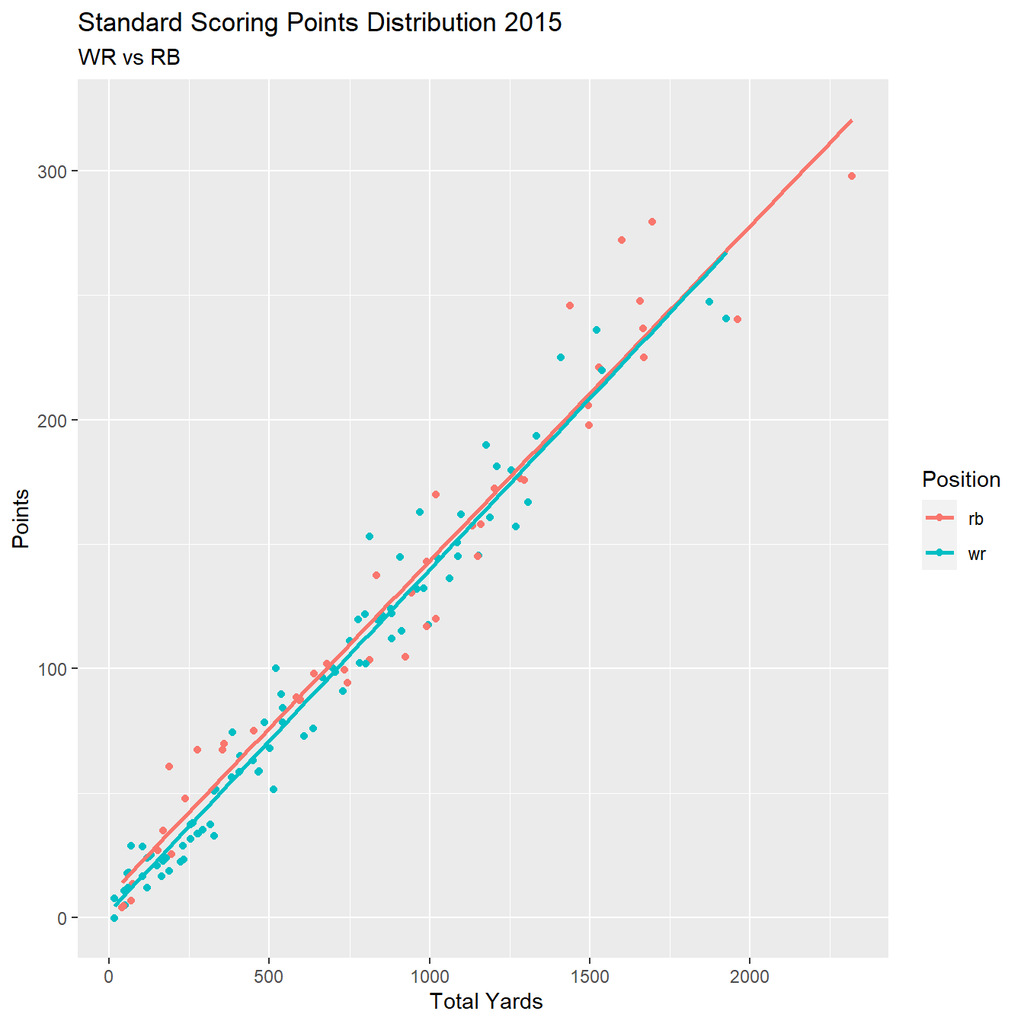

```
## [1] "The correlation between rushing yards and points scored 0.628335238389187"
```

```
## [1] "The correlation between receiving yards and points scored 0.564618120676817"
```

```
## [1] "The correlation between ruching touchdowns and points scored 0.57981316051379"
```

```
## [1] "The correlation between receiving touchdowns and points scored 0.493303074226689"
```

### PPR Scoring

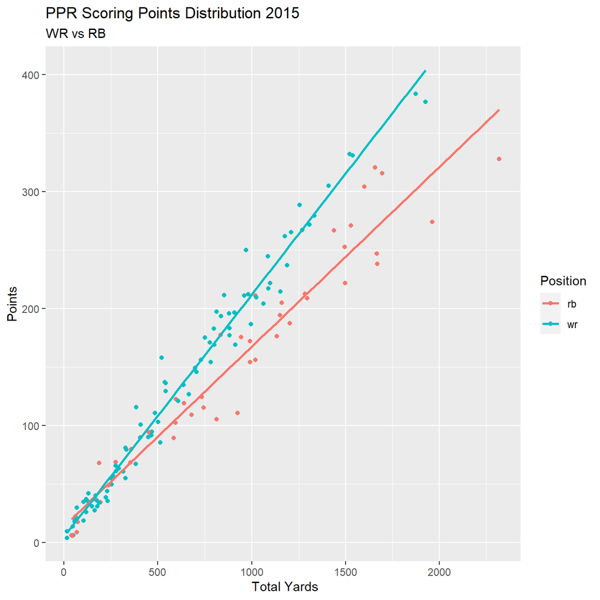

```
## [1] "The correlation between rushing yards and points scored 0.434175108916652"
```

```
## [1] "The correlation between receiving yards and points scored 0.74266932442586"
```

```
## [1] "The correlation between rushing touchdowns and points scored 0.382651080574327"
```

```
## [1] "The correlation between receiving touchdowns and points scored 0.638849688799032"
```

## 2016

### Summary

```
##   Player_Id              Year         Fumbles       Rushing_Yards
##  Length:179         Min.   :2016   Min.   :0.0000   Min.   :  -2.0
##  Class :character   1st Qu.:2016   1st Qu.:0.0000   1st Qu.:  13.5
##  Mode  :character   Median :2016   Median :0.0000   Median :  56.0
##                     Mean   :2016   Mean   :0.5084   Mean   : 273.8
##                     3rd Qu.:2016   3rd Qu.:1.0000   3rd Qu.: 364.5
##                     Max.   :2016   Max.   :5.0000   Max.   :2097.0
##  Receiving_Yards    Rushing_TD       Receptions      Recieving_TD
##  Min.   :   2.0   Min.   : 0.000   Min.   :  1.00   Min.   : 0.000
##  1st Qu.:  64.5   1st Qu.: 0.000   1st Qu.:  7.00   1st Qu.: 0.000
##  Median : 288.0   Median : 1.000   Median : 30.00   Median : 1.000
##  Mean   : 388.1   Mean   : 2.229   Mean   : 33.54   Mean   : 2.134
##  3rd Qu.: 606.5   3rd Qu.: 3.000   3rd Qu.: 53.50   3rd Qu.: 4.000
##  Max.   :1448.0   Max.   :17.000   Max.   :107.00   Max.   :12.000
##  Fantasy_Reception_Points Fantasy_Rushing_Points
##  Min.   :  1.00           Min.   :  0.10
##  1st Qu.:  7.00           1st Qu.:  1.80
##  Median : 30.00           Median :  7.60
##  Mean   : 33.54           Mean   : 40.76
##  3rd Qu.: 53.50           3rd Qu.: 55.75
##  Max.   :107.00           Max.   :304.70
##  Fantasy_Standard_Reciving_Points   Total_PPR     Total_Standard
##  Min.   :  0.20                   Min.   :  2.5   Min.   :  1.50
##  1st Qu.:  7.65                   1st Qu.: 42.9   1st Qu.: 29.10
##  Median : 37.50                   Median :115.5   Median : 82.30
##  Mean   : 51.62                   Mean   :124.9   Mean   : 91.35
##  3rd Qu.: 78.15                   3rd Qu.:193.3   3rd Qu.:132.55
##  Max.   :200.40                   Max.   :401.8   Max.   :321.80
##    Position
##  Length:179
##  Class :character
##  Mode  :character
##
##
##
```

### Standard Scoring

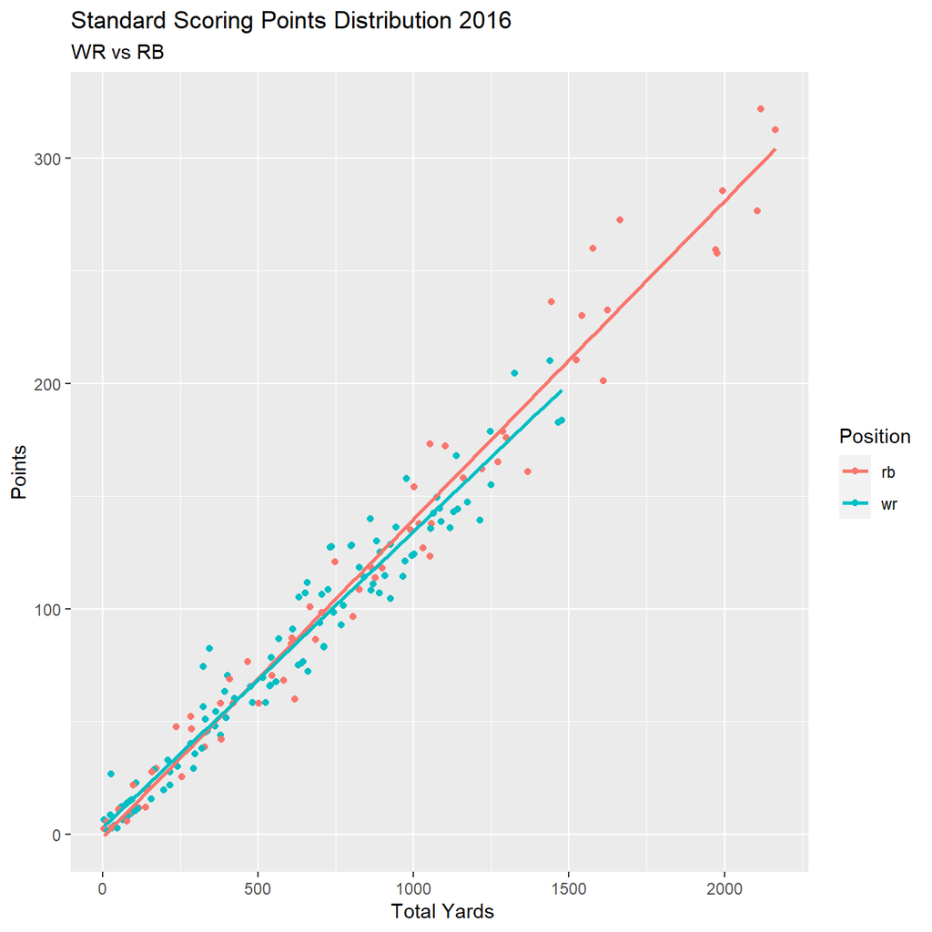

```
## [1] "The correlation between rushing yards and points scored 0.722154820110659"
```

```
## [1] "The correlation between receiving yards and points scored 0.511871618471247"
```

```
## [1] "The correlation between ruching touchdowns and points scored 0.707664936220189"
```

```
## [1] "The correlation between receiving touchdowns and points scored 0.438067026223584"
```

### PPR Scoring

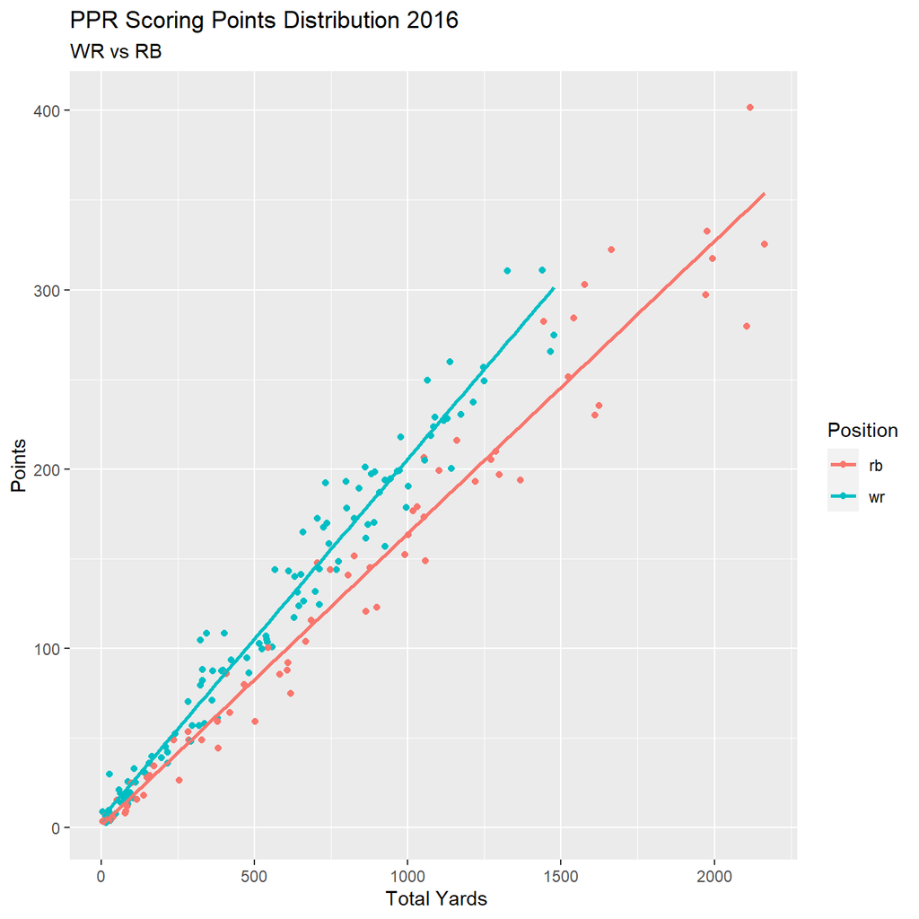

```
## [1] "The correlation between rushing yards and points scored 0.545779062187421"
```

```
## [1] "The correlation between receiving yards and points scored 0.694098696858508"
```

```
## [1] "The correlation between ruching touchdowns and points scored 0.542392890452094"
```

```
## [1] "The correlation between receiving touchdowns and points scored 0.58042803401272"
```

## 2017

### Summary

```
##   Player_Id              Year         Fumbles       Rushing_Yards
##  Length:221         Min.   :2017   Min.   :0.0000   Min.   :  -2.0
##  Class :character   1st Qu.:2017   1st Qu.:0.0000   1st Qu.:  13.0
##  Mode  :character   Median :2017   Median :0.0000   Median :  52.0
##                     Mean   :2017   Mean   :0.4615   Mean   : 290.1
##                     3rd Qu.:2017   3rd Qu.:0.0000   3rd Qu.: 425.0
##                     Max.   :2017   Max.   :5.0000   Max.   :2097.0
##  Receiving_Yards    Rushing_TD       Receptions      Recieving_TD
##  Min.   :   1.0   Min.   : 0.000   Min.   :  1.00   Min.   : 0.000
##  1st Qu.:  80.0   1st Qu.: 0.000   1st Qu.:  9.00   1st Qu.: 0.000
##  Median : 248.0   Median : 1.000   Median : 25.00   Median : 1.000
##  Mean   : 355.1   Mean   : 2.434   Mean   : 30.99   Mean   : 2.113
##  3rd Qu.: 525.0   3rd Qu.: 3.000   3rd Qu.: 50.00   3rd Qu.: 3.000
##  Max.   :1533.0   Max.   :17.000   Max.   :112.00   Max.   :13.000
##  Fantasy_Reception_Points Fantasy_Rushing_Points
##  Min.   :  1.00           Min.   :  0.10
##  1st Qu.:  9.00           1st Qu.:  1.80
##  Median : 25.00           Median :  8.10
##  Mean   : 30.99           Mean   : 43.62
##  3rd Qu.: 50.00           3rd Qu.: 58.40
##  Max.   :112.00           Max.   :304.70
##  Fantasy_Standard_Reciving_Points   Total_PPR     Total_Standard
##  Min.   :  0.30                   Min.   :  3.5   Min.   :  1.50
##  1st Qu.:  9.30                   1st Qu.: 39.0   1st Qu.: 28.60
##  Median : 34.40                   Median :108.5   Median : 77.20
##  Mean   : 48.19                   Mean   :121.9   Mean   : 90.89
##  3rd Qu.: 73.40                   3rd Qu.:180.8   3rd Qu.:128.00
##  Max.   :215.80                   Max.   :405.9   Max.   :341.90
##    Position
##  Length:221
##  Class :character
##  Mode  :character
##
##
##
```

### Standard Scoring

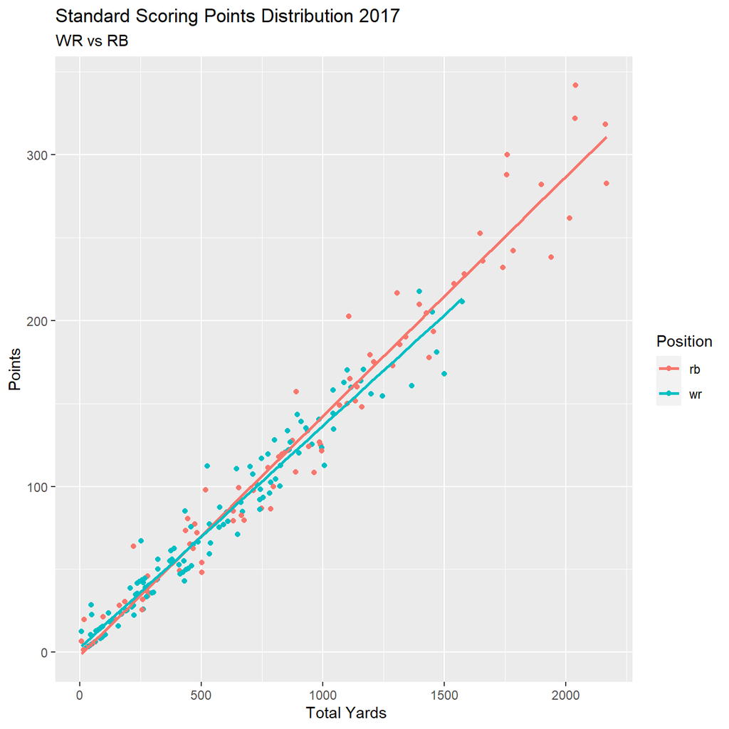

```
## [1] "The correlation between rushing yards and points scored 0.761995192231403"
```

```
## [1] "The correlation between receiving yards and points scored 0.49427185748568"
```

```
## [1] "The correlation between ruching touchdowns and points scored 0.757890370258625"
```

```
## [1] "The correlation between receiving touchdowns and points scored 0.418501385169962"
```

### PPR Scoring

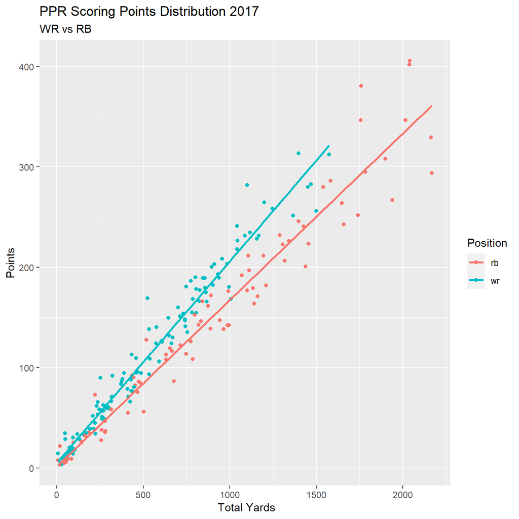

```
## [1] "The correlation between rushing yards and points scored 0.6136414541227"
```

```
## [1] "The correlation between receiving yards and points scored 0.663864899663772"
```

```
## [1] "The correlation between ruching touchdowns and points scored 0.61678994254881"
```

```
## [1] "The correlation between receiving touchdowns and points scored 0.553220962681487"
```

## 2018

### Summary

```
##   Player_Id              Year         Fumbles       Rushing_Yards
##  Length:277         Min.   :2018   Min.   :0.0000   Min.   :  -2.0
##  Class :character   1st Qu.:2018   1st Qu.:0.0000   1st Qu.:  13.0
##  Mode  :character   Median :2018   Median :0.0000   Median :  56.0
##                     Mean   :2018   Mean   :0.4838   Mean   : 283.3
##                     3rd Qu.:2018   3rd Qu.:1.0000   3rd Qu.: 382.0
##                     Max.   :2018   Max.   :7.0000   Max.   :2097.0
##  Receiving_Yards    Rushing_TD      Receptions      Recieving_TD
##  Min.   :   1.0   Min.   : 0.00   Min.   :  1.00   Min.   : 0.000
##  1st Qu.:  67.0   1st Qu.: 0.00   1st Qu.:  8.00   1st Qu.: 0.000
##  Median : 213.0   Median : 1.00   Median : 22.00   Median : 1.000
##  Mean   : 348.8   Mean   : 2.48   Mean   : 30.64   Mean   : 2.195
##  3rd Qu.: 566.0   3rd Qu.: 3.00   3rd Qu.: 45.00   3rd Qu.: 4.000
##  Max.   :1677.0   Max.   :17.00   Max.   :125.00   Max.   :15.000
##  Fantasy_Reception_Points Fantasy_Rushing_Points
##  Min.   :  1.00           Min.   :  0.10
##  1st Qu.:  8.00           1st Qu.:  1.80
##  Median : 22.00           Median :  9.30
##  Mean   : 30.64           Mean   : 43.21
##  3rd Qu.: 45.00           3rd Qu.: 58.40
##  Max.   :125.00           Max.   :304.70
##  Fantasy_Standard_Reciving_Points   Total_PPR     Total_Standard
##  Min.   :  0.10                   Min.   :  1.5   Min.   :  0.5
##  1st Qu.:  8.20                   1st Qu.: 43.4   1st Qu.: 29.6
##  Median : 27.60                   Median :101.5   Median : 73.5
##  Mean   : 48.05                   Mean   :120.9   Mean   : 90.3
##  3rd Qu.: 75.70                   3rd Qu.:173.5   3rd Qu.:126.9
##  Max.   :223.20                   Max.   :456.4   Max.   :349.4
##    Position
##  Length:277
##  Class :character
##  Mode  :character
##
##
##
```

### Standard Scoring

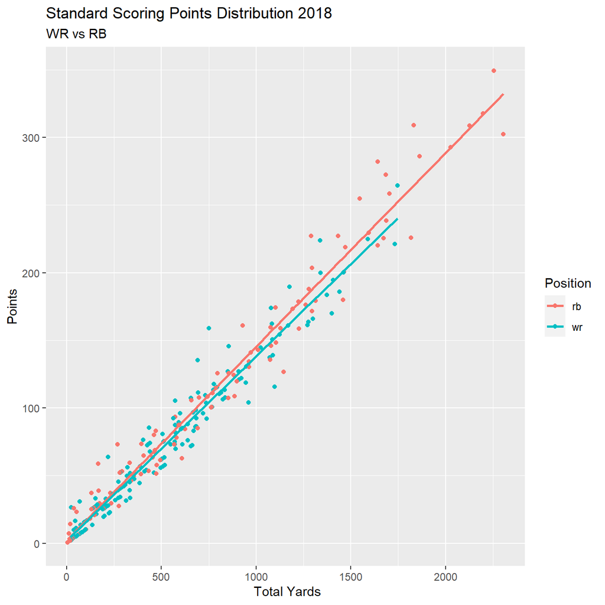

```
## [1] "The correlation between rushing yards and points scored 0.729213567800765"
```

```
## [1] "The correlation between receiving yards and points scored 0.525688324793883"
```

```
## [1] "The correlation between ruching touchdowns and points scored 0.702411979097764"
```

```
## [1] "The correlation between receiving touchdowns and points scored 0.493001421784287"
```

### PPR Scoring

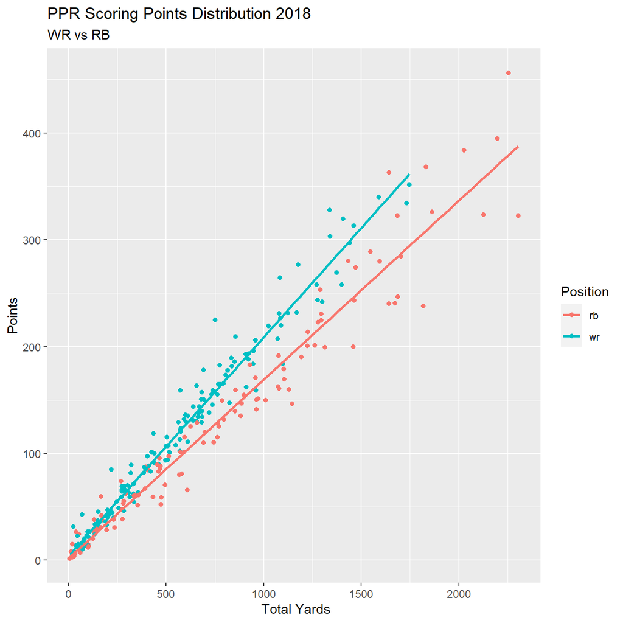

```
## [1] "The correlation between rushing yards and points scored 0.567578430516183"
```

```
## [1] "The correlation between receiving yards and points scored 0.696747287450408"
```

```
## [1] "The correlation between ruching touchdowns and points scored 0.548492107092078"
```

```
## [1] "The correlation between receiving touchdowns and points scored 0.620512338434686"
```

## 2019

### Summary

```
##   Player_Id              Year         Fumbles       Rushing_Yards
##  Length:299         Min.   :2019   Min.   :0.0000   Min.   :  -2.0
##  Class :character   1st Qu.:2019   1st Qu.:0.0000   1st Qu.:  13.5
##  Mode  :character   Median :2019   Median :0.0000   Median :  55.0
##                     Mean   :2019   Mean   :0.4281   Mean   : 264.2
##                     3rd Qu.:2019   3rd Qu.:0.0000   3rd Qu.: 366.5
##                     Max.   :2019   Max.   :7.0000   Max.   :2097.0
##  Receiving_Yards    Rushing_TD       Receptions      Recieving_TD
##  Min.   :   1.0   Min.   : 0.000   Min.   :  1.00   Min.   : 0.000
##  1st Qu.:  57.0   1st Qu.: 0.000   1st Qu.:  7.00   1st Qu.: 0.000
##  Median : 207.0   Median : 0.000   Median : 21.00   Median : 1.000
##  Mean   : 322.2   Mean   : 2.197   Mean   : 28.86   Mean   : 1.853
##  3rd Qu.: 449.5   3rd Qu.: 3.000   3rd Qu.: 42.50   3rd Qu.: 3.000
##  Max.   :1725.0   Max.   :17.000   Max.   :149.00   Max.   :11.000
##  Fantasy_Reception_Points Fantasy_Rushing_Points
##  Min.   :  1.00           Min.   :  0.10
##  1st Qu.:  7.00           1st Qu.:  1.75
##  Median : 21.00           Median :  8.90
##  Mean   : 28.86           Mean   : 39.61
##  3rd Qu.: 42.50           3rd Qu.: 54.45
##  Max.   :149.00           Max.   :304.70
##  Fantasy_Standard_Reciving_Points   Total_PPR      Total_Standard
##  Min.   :  0.10                   Min.   :  2.90   Min.   :  1.50
##  1st Qu.:  7.05                   1st Qu.: 39.45   1st Qu.: 24.90
##  Median : 26.40                   Median : 86.70   Median : 62.20
##  Mean   : 43.33                   Mean   :110.94   Mean   : 82.08
##  3rd Qu.: 61.45                   3rd Qu.:165.15   3rd Qu.:121.70
##  Max.   :226.50                   Max.   :467.20   Max.   :351.20
##    Position
##  Length:299
##  Class :character
##  Mode  :character
##
##
##
```

### Standard Scoring

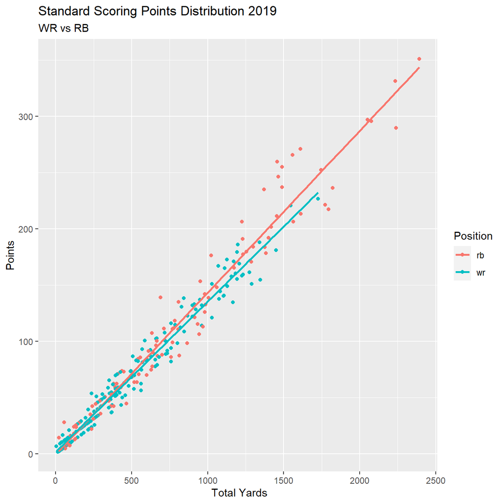

```
## [1] "The correlation between rushing yards and points scored 0.744253017309622"
```

```
## [1] "The correlation between receiving yards and points scored 0.549031489417825"
```

```
## [1] "The correlation between ruching touchdowns and points scored 0.739910524220601"
```

```
## [1] "The correlation between receiving touchdowns and points scored 0.482705346186638"
```

### PPR Scoring

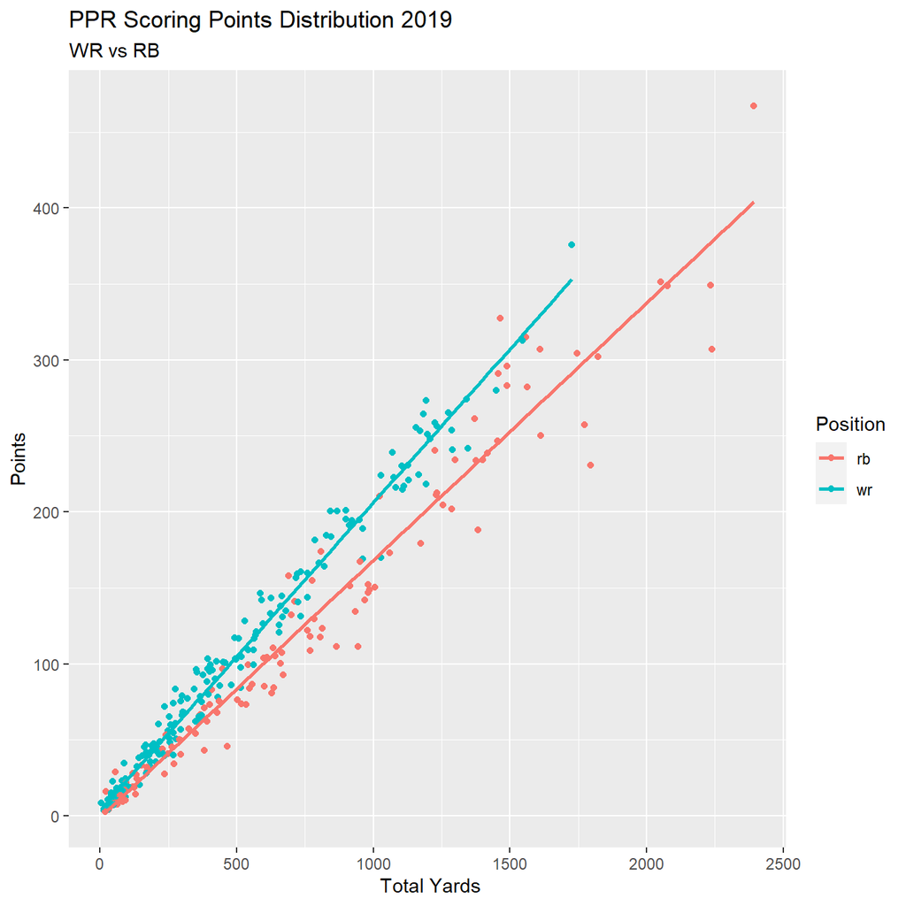

```
## [1] "The correlation between rushing yards and points scored 0.593937207052221"
```

```
## [1] "The correlation between receiving yards and points scored 0.709351019865866"
```

```
## [1] "The correlation between ruching touchdowns and points scored 0.600030490182896"
```

```
## [1] "The correlation between receiving touchdowns and points scored 0.600122045310461"
```

## 2020

### Summary

```
##   Player_Id              Year         Fumbles      Rushing_Yards
##  Length:317         Min.   :2020   Min.   :0.000   Min.   :   1.0
##  Class :character   1st Qu.:2020   1st Qu.:0.000   1st Qu.:  15.0
##  Mode  :character   Median :2020   Median :0.000   Median :  64.0
##                     Mean   :2020   Mean   :0.489   Mean   : 278.3
##                     3rd Qu.:2020   3rd Qu.:1.000   3rd Qu.: 419.0
##                     Max.   :2020   Max.   :7.000   Max.   :2097.0
##  Receiving_Yards    Rushing_TD       Receptions      Recieving_TD
##  Min.   :   2.0   Min.   : 0.000   Min.   :  1.00   Min.   : 0.000
##  1st Qu.:  53.0   1st Qu.: 0.000   1st Qu.:  6.00   1st Qu.: 0.000
##  Median : 164.0   Median : 0.000   Median : 19.00   Median : 1.000
##  Mean   : 305.4   Mean   : 2.356   Mean   : 28.09   Mean   : 1.918
##  3rd Qu.: 441.0   3rd Qu.: 3.000   3rd Qu.: 44.00   3rd Qu.: 3.000
##  Max.   :1535.0   Max.   :17.000   Max.   :127.00   Max.   :15.000
##  Fantasy_Reception_Points Fantasy_Rushing_Points
##  Min.   :  1.00           Min.   :  0.10
##  1st Qu.:  6.00           1st Qu.:  1.70
##  Median : 19.00           Median :  9.30
##  Mean   : 28.09           Mean   : 41.97
##  3rd Qu.: 44.00           3rd Qu.: 58.70
##  Max.   :127.00           Max.   :304.70
##  Fantasy_Standard_Reciving_Points   Total_PPR     Total_Standard
##  Min.   :  0.20                   Min.   :  1.7   Min.   :  0.70
##  1st Qu.:  6.80                   1st Qu.: 32.4   1st Qu.: 22.10
##  Median : 19.90                   Median : 95.4   Median : 68.10
##  Mean   : 42.05                   Mean   :111.1   Mean   : 83.04
##  3rd Qu.: 60.50                   3rd Qu.:167.5   3rd Qu.:125.00
##  Max.   :217.60                   Max.   :375.8   Max.   :310.10
##    Position
##  Length:317
##  Class :character
##  Mode  :character
##
##
##
```

### Standard Scoring

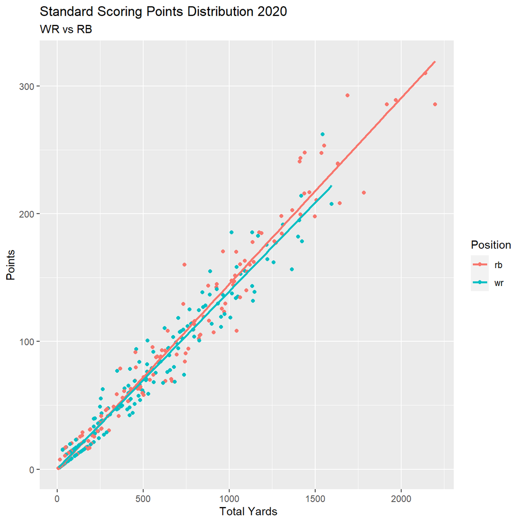

```
## [1] "The correlation between rushing yards and points scored 0.715361626215507"
```

```
## [1] "The correlation between receiving yards and points scored 0.487989971221931"
```

```
## [1] "The correlation between ruching touchdowns and points scored 0.717754812334346"
```

```
## [1] "The correlation between receiving touchdowns and points scored 0.445611593722671"
```

### PPR Scoring

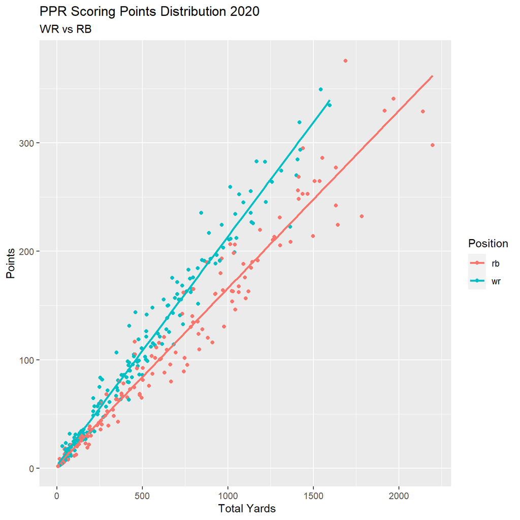

```
## [1] "The correlation between rushing yards and points scored 0.53097971793267"
```

```
## [1] "The correlation between receiving yards and points scored 0.682989386670525"
```

```
## [1] "The correlation between ruching touchdowns and points scored 0.544619574389235"
```

```
## [1] "The correlation between receiving touchdowns and points scored 0.596885273328576"
```